# Pathway analysis: Gene Set Enrichment Analysis (GSEA)

CCDL for ALSF

2024

## Objectives

This notebook will demonstrate how to:

- Prepare tabular data of gene-level statistics for use with Gene Set Enrichment Analysis (GSEA)
- Access [Molecular Signatures Database gene set collections](https://www.gsea-msigdb.org/gsea/msigdb/collections.jsp) via the `msigdbr` package
- Perform GSEA with the `clusterProfiler` package
- Visualize GSEA results with the `enrichplot` package

In this notebook, we’ll analyze the differential expression results from the last notebook.

GSEA is a functional class scoring (FCS) approach to pathway analysis that was first introduced in [Subramanian *et al.* (2005)](https://doi.org/10.1073/pnas.0506580102). The rationale behind FCS approaches is that small changes in individual genes that participate in the same biological process or pathway can be significant and of biological interest.

There are 3 general steps in FCS methods ([Khatri *et al.* 2012](https://doi.org/10.1371/journal.pcbi.1002375)):

1. Calculate a gene-level statistic (here, we’ll use the summary log fold changes in our DESeq2 results)
2. Aggregate gene-level statistics into a pathway-level statistic
3. Assess the statistical significance of the pathway-level statistic

#### Other resources

- For another example using `clusterProfiler` for GSEA, see [*Intro to DGE: Functional Analysis.* from Harvard Chan Bioinformatics Core Training.](https://hbctraining.github.io/Training-modules/DGE-functional-analysis/lessons/02_functional_analysis.html)
- The way we’ll use `clusterProfiler` here uses `fgsea` (Fast Gene Set Enrichment Analysis) under the hood. You can read more about `fgsea` in [Korotkevich *et al.* (2021)](https://doi.org/10.1101/060012).
- See the [refine.bio examples for “Gene set enrichment analysis - RNA-seq”](https://alexslemonade.github.io/refinebio-examples/03-rnaseq/pathway-analysis_rnaseq_02_gsea.html) from which this material has been adapted.

## Set up

### Libraries

```r
# set seed for reproducibility
set.seed(2025)

# Package to run GSEA
library(clusterProfiler)
# Package that contains the MSigDB gene sets in tidy format
library(msigdbr)
```

### Directories and Files

#### Directories

```r
# We'll use the differential expression results as GSEA input
rms_analysis_dir <- file.path("analysis", "rms")

# We'll create a directory to specifically hold the pathway results if it doesn't
# exist yet
results_dir <- file.path(rms_analysis_dir, "pathway-analysis")
fs::dir_create(results_dir)
```

#### Input files

```r
input_file <- file.path(rms_analysis_dir,
                        "deseq",
                        "rms_myoblast_deseq_results.tsv")
```

#### Output files

We’ll save our table of GSEA results as a TSV.

```r
output_file <- file.path(results_dir,
                         "rms_myoblast_gsea_results.tsv")
```

## Gene sets

We will use gene sets from the [Molecular Signatures Database (MSigDB)](https://www.gsea-msigdb.org/gsea/msigdb/index.jsp) from the Broad Institute ([Subramanian, Tamayo *et al.* 2005](https://doi.org/10.1073/pnas.0506580102)). The [`msigdbr`](https://cran.r-project.org/web/packages/msigdbr/index.html) package contains MSigDB datasets already in the tidy format required by `clusterProfiler` and supports multiple organisms.

Let’s take a look at what organisms the package supports.

```r
msigdbr_species()
```

| species_name | species_common_name |
| --- | --- |
| Anolis carolinensis | Carolina anole, green anole |
| Bos taurus | bovine, cattle, cow, dairy cow, domestic cattle, domestic cow, ox, oxen |
| Caenorhabditis elegans | NA |
| Canis lupus familiaris | dog, dogs |
| Danio rerio | leopard danio, zebra danio, zebra fish, zebrafish |
| Drosophila melanogaster | fruit fly |
| Equus caballus | domestic horse, equine, horse |
| Felis catus | cat, cats, domestic cat |
| Gallus gallus | bantam, chicken, chickens, Gallus domesticus |
| Homo sapiens | human |

[output cut: 10 more lines]

MSigDB contains 8 different gene set collections.

```
H: hallmark gene sets
C1: positional gene sets
C2: curated gene sets
C3: motif gene sets
C4: computational gene sets
C5: GO gene sets
C6: oncogenic signatures
C7: immunologic signatures
```

We’ll use the Hallmark collection for GSEA. Here’s an excerpt of the [collection description](https://www.gsea-msigdb.org/gsea/msigdb/collection_details.jsp#H):

> Hallmark gene sets summarize and represent specific well-defined biological states or processes and display coherent expression. These gene sets were generated by a computational methodology based on identifying gene set overlaps and retaining genes that display coordinate expression. The hallmarks reduce noise and redundancy and provide a better delineated biological space for GSEA.

Notably, there are only 50 gene sets included in this collection. The fewer gene sets we test, the lower our multiple hypothesis testing burden.

We can retrieve only the Hallmark gene sets by specifying `category = "H"` to the `msigdbr()` function.

```r
hs_hallmarks_df <- msigdbr(species = "Homo sapiens",
                           category = "H")
```

## Gene Set Enrichment Analysis

*Adapted from [refine.bio examples](https://github.com/AlexsLemonade/refinebio-examples/blob/33cdeff66d57f9fe8ee4fcb5156aea4ac2dce07f/03-rnaseq/pathway-analysis_rnaseq_02_gsea.Rmd)*

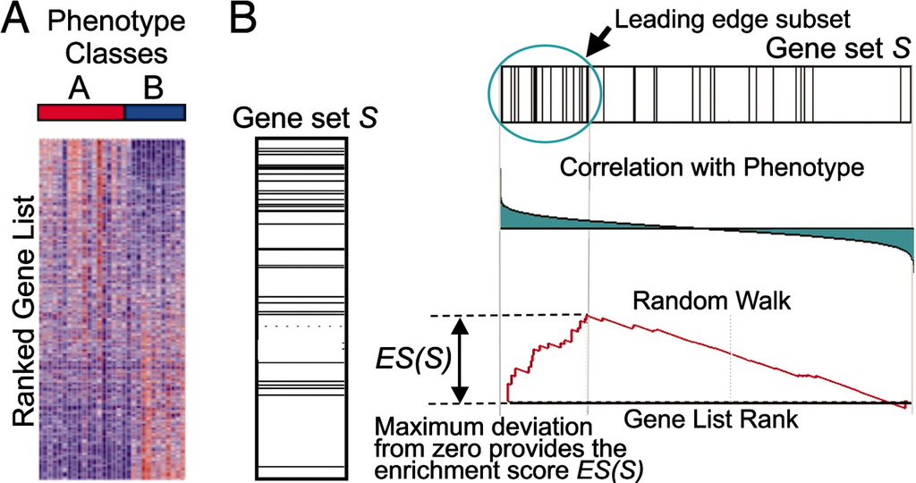

**Figure 1. [Subramanian *et al.* (2005)](https://doi.org/10.1073/pnas.0506580102).**

GSEA calculates a pathway-level metric, called an enrichment score (sometimes abbreviated as ES), by ranking genes by a gene-level statistic. This score reflects whether or not a gene set or pathway is over-represented at the top or bottom of the gene rankings ([Subramanian *et al.* 2005](https://doi.org/10.1073/pnas.0506580102); [Yu](http://yulab-smu.top/clusterProfiler-book/chapter2.html#gene-set-enrichment-analysis))

Specifically, all genes are ranked from most positive to most negative based on their statistic and a running sum is calculated: Starting with the most highly ranked genes, the running sum increases for each gene in the pathway and decreases for each gene not in the pathway. The enrichment score for a pathway is the running sum’s maximum deviation from zero. GSEA also assesses statistical significance of the scores for each pathway through permutation testing. As a result, each input pathway will have a p-value associated with it that is then corrected for multiple hypothesis testing ([Subramanian *et al.* 2005](https://doi.org/10.1073/pnas.0506580102); [Yu](http://yulab-smu.top/clusterProfiler-book/chapter2.html#gene-set-enrichment-analysis)).

The implementation of GSEA we use here requires a gene list ordered by some statistic and input gene sets. When you use previously computed gene-level statistics with GSEA, it is called GSEA pre-ranked.

## DESeq2 results

```r
deseq_df <- readr::read_tsv(input_file)
```

```r
head(deseq_df)
```

| ensembl_id | baseMean | log2FoldChange | lfcSE | pvalue | padj | gene_symbol | SCPCL000478.mean | SCPCL000478.detected | SCPCL000479.mean | SCPCL000479.detected | SCPCL000480.mean | SCPCL000480.detected | SCPCL000481.mean | SCPCL000481.detected | SCPCL000483.mean | SCPCL000483.detected | SCPCL000484.mean | SCPCL000484.detected | SCPCL000488.mean | SCPCL000488.detected | SCPCL000491.mean | SCPCL000491.detected | SCPCL000495.mean | SCPCL000495.detected | SCPCL000498.mean | SCPCL000498.detected |
| --- | --- | --- | --- | --- | --- | --- | --- | --- | --- | --- | --- | --- | --- | --- | --- | --- | --- | --- | --- | --- | --- | --- | --- | --- | --- | --- |
| ENSG00000000003 | 101.051149 | 0.41081019 | 0.5086436 | 0.3142629 | 0.6537987 | TSPAN6 | 0.008832039 | 0.8070656 | 0.017720180 | 1.6397778 | 0.052098408 | 4.8283121 | 0.063798376 | 5.9896657 | 0.0009505703 | 0.09505703 | 0.023023023 | 2.2451022 | 0.029668991 | 2.7565593 | 0.0413815575 | 3.86119257 | 0.037366280 | 3.570890 | 0.006492590 | 0.6351447 |
| ENSG00000000005 | 15.069745 | 0.74492606 | 0.9924699 | 0.1067501 | 0.3683125 | TNMD | 0.002131871 | 0.1675042 | 0.002644803 | 0.1586882 | 0.008551506 | 0.8288383 | 0.005483497 | 0.4956237 | 0.0000000000 | 0.00000000 | 0.002717003 | 0.2717003 | 0.001549873 | 0.1439167 | 0.0004887586 | 0.04887586 | 0.061473557 | 4.731053 | 0.001552576 | 0.1411433 |
| ENSG00000000419 | 445.709446 | -0.19825443 | 0.4438067 | 0.5944052 | 0.8500990 | DPM1 | 0.091975027 | 7.5224608 | 0.072996562 | 6.1094948 | 0.089198790 | 8.3015393 | 0.240113888 | 20.0569440 | 0.0137832700 | 1.23574144 | 0.079365079 | 7.3788074 | 0.168714713 | 14.1591941 | 0.4217986315 | 28.70641903 | 0.140274220 | 12.671388 | 0.131545519 | 11.0374030 |
| ENSG00000000457 | 287.056388 | -0.46547999 | 0.5306264 | 0.2625545 | 0.6000687 | SCYL3 | 0.035937262 | 3.0150754 | 0.023009786 | 1.9836022 | 0.052624655 | 5.0651230 | 0.139723716 | 12.4116841 | 0.0057034221 | 0.52281369 | 0.055055055 | 5.1194051 | 0.180228053 | 14.6795085 | 0.1769305963 | 14.41837732 | 0.076389935 | 7.141781 | 0.057163020 | 5.3493296 |
| ENSG00000000460 | 553.739704 | -0.09800858 | 0.4282541 | 0.7857861 | 0.9322829 | C1orf112 | 0.063651591 | 4.7053449 | 0.081195451 | 6.4268712 | 0.109064597 | 9.6566241 | 0.269113150 | 21.2063693 | 0.0080798479 | 0.61787072 | 0.084084084 | 7.7077077 | 0.184434850 | 14.6795085 | 0.4343434343 | 26.66992506 | 0.141027573 | 12.159108 | 0.119266055 | 9.6683133 |
| ENSG00000000938 | 5.649236 | 0.15509904 | 0.6557151 | 0.7054890 | 0.9000655 | FGR | 0.014770824 | 0.9593422 | 0.003173764 | 0.2380323 | 0.001973425 | 0.1973425 | 0.004007171 | 0.3585363 | 0.0009505703 | 0.09505703 | 0.002145002 | 0.1859002 | 0.009077826 | 0.7860069 | 0.0037471489 | 0.34213099 | 0.009944252 | 0.919090 | 0.006774876 | 0.5928017 |

This data frame uses Ensembl gene identifiers. We’ll need to make sure our gene sets use the same identifiers. Let’s take a look at the first few rows of the data frame that contains the hallmark gene sets.

[output not shown]

[output cut: 990 more lines]

We can see that the gene sets from `msigdbr` have Ensembl gene identifiers associated with them, so we don’t need to do any conversion. However, we’ll need to pass the correct column to the function that runs GSEA.

If we needed to do gene identifier conversion, we would likely use the `AnnotationDbi` package. You can see an example in this Harvard Chan Bioinformatics Core Training material: https://hbctraining.github.io/DGE_workshop_salmon_online/lessons/AnnotationDbi_lesson.html

One good thing about Ensembl gene identifiers is that they are less likely to be duplicated than, for example, gene symbols. (Multiple Ensembl gene identifiers can map to the same symbol.)

The GSEA approach requires discriminating between genes that are in a gene set and those that are not. Practically speaking, gene sets are just collections of gene identifiers! When the function we use for GSEA pre-ranked gets a list with duplicated gene identifiers, it can produce unexpected results. So, let’s check for duplicates in the data frame of DESeq2 results.

```r
any(duplicated(deseq_df$ensembl_id))
```

```
[1] FALSE
```

There are no duplicates for us to worry about!

### Pre-ranked list

The `GSEA()` function takes a pre-ranked (sorted) named vector of statistics, where the names in the vector are gene identifiers. This is step 1 – gene-level statistics.

```r
lfc_vector <- deseq_df |>
  # Extract a vector of `log2FoldChange` named by `ensembl_id`
  dplyr::pull(log2FoldChange, name = ensembl_id)
lfc_vector <- sort(lfc_vector, decreasing = TRUE)
```

Let’s look at the top ranked values.

```r
# Look at first entries of the log fold change vector
head(lfc_vector)
```

```
ENSG00000263366 ENSG00000223760 ENSG00000253377 ENSG00000265843 ENSG00000104722 ENSG00000228835
      11.364714       10.573752       10.476990       10.199449       10.019651        9.898818
```

And the bottom of the list.

```r
# Look at the last entries of the log fold change vector
tail(lfc_vector)
```

```
ENSG00000269186 ENSG00000268388 ENSG00000165606 ENSG00000285640 ENSG00000118432 ENSG00000184221
      -10.93216       -11.35119       -11.36925       -11.90034       -11.92082       -12.12577
```

## Run GSEA

Now for the analysis!

We can use the `GSEA()` function to perform GSEA with any generic set of gene sets, but there are several functions for using specific, commonly used gene sets (e.g., `gseKEGG()`).

```r
gsea_results <- GSEA(geneList = lfc_vector,  # ordered ranked gene list
                     minGSSize = 25,  # minimum gene set size
                     maxGSSize = 500,  # maximum gene set set
                     pvalueCutoff = 0.05,
                     pAdjustMethod = "BH",  # correction for multiple hypothesis testing
                     TERM2GENE = dplyr::select(hs_hallmarks_df,
                                               gs_name,
                                               ensembl_gene))  # pass the correct identifier column
```

Let’s take a look at the GSEA results.

```r
View(
  gsea_results@result |>
    dplyr::arrange(dplyr::desc(NES))
)
```

Normalized enrichment scores (NES) are enrichment scores that are scaled to make gene sets that contain different number of genes comparable.

Pathways with significant, highly positive NES are enriched in ERMS myoblasts, whereas pathways with significant, highly negative NES are enriched in ARMS myoblasts.

Let’s write these results to a file.

```r
gsea_results@result |>
  readr::write_tsv(output_file)
```

### Visualizing GSEA results

We can visualize GSEA results for individual pathways or gene sets using `enrichplot::gseaplot()`. Let’s take a look at 3 different pathways – one with a highly positive NES, one with a highly negative NES, and one that was not a significant result – to get more insight into how ES are calculated.

#### Highly Positive NES

Let’s take look at a pathway with a highly positive NES (`HALLMARK_MYC_TARGETS_V2`) using a GSEA plot.

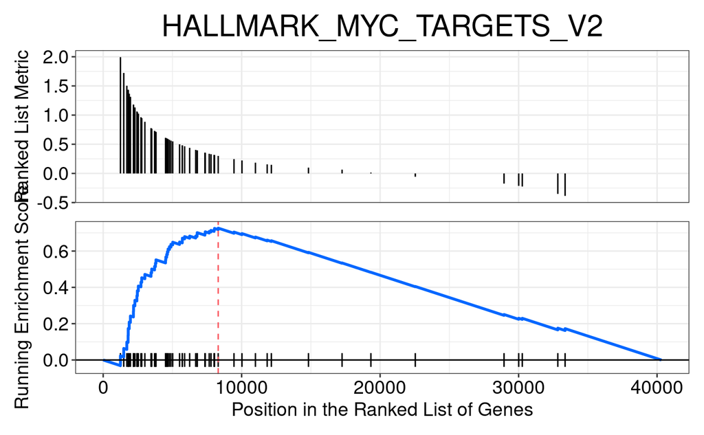

```r
enrichplot::gseaplot(gsea_results,
                     geneSetID = "HALLMARK_MYC_TARGETS_V2",
                     title = "HALLMARK_MYC_TARGETS_V2",
                     color.line = "#0066FF")
```

Notice how the genes that are in the gene set, indicated by the black bars, tend to be on the left side of the graph indicating that they have positive gene-level scores.

#### Highly Negative NES

The gene set `HALLMARK_MYOGENESIS` had a highly negative NES.

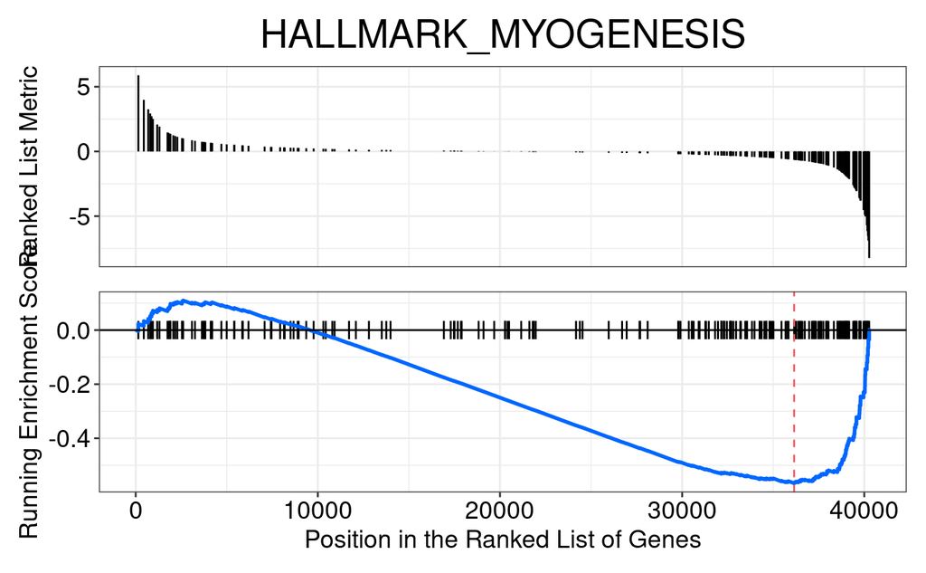

```r
enrichplot::gseaplot(gsea_results,
                     geneSetID = "HALLMARK_MYOGENESIS",
                     title = "HALLMARK_MYOGENESIS",
                     color.line = "#0066FF")
```

This gene set shows the opposite pattern – genes in the pathway tend to be on the right side of the graph.

#### A non-significant result

The `@results` slot will only show gene sets that pass the `pvalueCutoff` threshold we supplied to `GSEA()`, but we can plot any gene set so long as we know its name. Let’s look at `HALLMARK_P53_PATHWAY`, which was not in the results we viewed earlier.

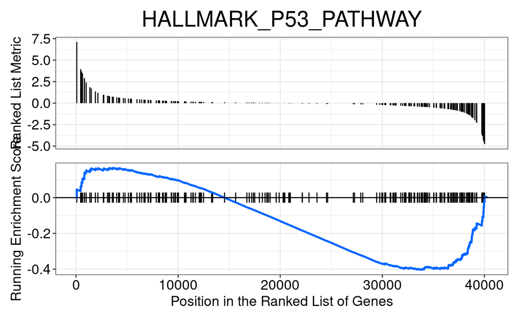

```r
enrichplot::gseaplot(gsea_results,
                     geneSetID = "HALLMARK_P53_PATHWAY",
                     title = "HALLMARK_P53_PATHWAY",
                     color.line = "#0066FF")
```

Genes in the pathway are distributed more evenly throughout the ranked list, resulting in a more “middling” score.

*Note: The plots returned by `enrichplot::gseaplot` are ggplots, so we could use `ggplot2::ggsave()` to save them to file if we wanted to.*